# Análisis exploratorio de datos — Cohorte ERC

Seminario de Epidemiología Clínica II — Módulo 2

Julián Camilo Velásquez Paz

2026-11-01

```r
library(tidyverse)
library(here)
library(skimr)
library(gtsummary)
library(naniar)
library(corrplot)

# Cargar base analítica
base <- readRDS(here("data", "processed", "base_analitica_v1.0.rds"))
cat("Base cargada:", nrow(base), "participantes,", ncol(base), "variables\n")
```

```
## Base cargada: 300 participantes, 55 variables
```

# 1 Descripción de la base de datos

La base analítica incluye 300 participantes con enfermedad renal crónica en estadios G2 a G4, seguidos durante 24 meses con dos puntos de evaluación (mes 12 y mes 24).

## 1.1 Flujo de participantes

```r
flujo <- tibble(
  Etapa = c(
    "Participantes en la base original",
    "Pérdida de seguimiento al mes 12",
    "Pérdida de seguimiento al mes 24",
    "Participantes con seguimiento completo al mes 24",
    "Participantes con desenlace (progresión G5/TRR)"
  ),
  N = c(
    nrow(base),
    sum(base$perdida_seguimiento_m12, na.rm = TRUE),
    sum(base$perdida_seguimiento_m24, na.rm = TRUE),
    sum(!base$perdida_seguimiento_m24, na.rm = TRUE),
    sum(base$progresion_g5_o_trr, na.rm = TRUE)
  ),
  Porcentaje = c(
    "100%",
    paste0(round(mean(base$perdida_seguimiento_m12, na.rm=TRUE)*100,1), "%"),
    paste0(round(mean(base$perdida_seguimiento_m24, na.rm=TRUE)*100,1), "%"),
    paste0(round(mean(!base$perdida_seguimiento_m24, na.rm=TRUE)*100,1), "%"),
    paste0(round(mean(base$progresion_g5_o_trr, na.rm=TRUE)*100,1), "%")
  )
)

knitr::kable(flujo, caption = "Tabla. Flujo de participantes en la cohorte")
```

Tabla. Flujo de participantes en la cohorte

| Etapa | N | Porcentaje |
| --- | --- | --- |
| Participantes en la base original | 300 | 100% |
| Pérdida de seguimiento al mes 12 | 37 | 12.3% |
| Pérdida de seguimiento al mes 24 | 54 | 18% |
| Participantes con seguimiento completo al mes 24 | 246 | 82% |
| Participantes con desenlace (progresión G5/TRR) | 33 | 11% |

**Interpretación:** La retención de la cohorte es alta, con aproximadamente el 82% de los participantes completando el seguimiento al mes 24. Las pérdidas al mes 12 (~12%) y al mes 24 (~18%) se consideran aceptables para un estudio longitudinal de esta naturaleza y permiten mantener un poder estadístico adecuado para el análisis del desenlace.

# 2 Resumen estadístico general

```r
# Resumen completo por tipo de variable
skim(base %>%
       select(edad, estadio_basal, sexo, diabetes, hipertension,
              tfg_ml_min_basal, creatinina_mg_dl_basal,
              hemoglobina_g_dl_basal, albumina_g_dl_basal,
              proteinuria_mg_g_basal, pas_mmhg_basal,
              progresion_g5_o_trr, tiempo_seguimiento_dias))
```

Data summary

| Name | %>%(…) |
| --- | --- |
| Number of rows | 300 |
| Number of columns | 13 |
| _______________________ |  |
| Column type frequency: |  |
| factor | 2 |
| logical | 3 |
| numeric | 8 |
| ________________________ |  |
| Group variables | None |

**Variable type: factor**

| skim_variable | n_missing | complete_rate | ordered | n_unique | top_counts |
| --- | --- | --- | --- | --- | --- |
| estadio_basal | 0 | 1 | TRUE | 4 | G3a: 93, G3b: 85, G2: 69, G4: 53 |
| sexo | 0 | 1 | FALSE | 2 | Fem: 157, Mas: 143 |

**Variable type: logical**

| skim_variable | n_missing | complete_rate | mean | count |
| --- | --- | --- | --- | --- |
| diabetes | 0 | 1 | 0.41 | FAL: 178, TRU: 122 |
| hipertension | 0 | 1 | 0.86 | TRU: 259, FAL: 41 |
| progresion_g5_o_trr | 0 | 1 | 0.11 | FAL: 267, TRU: 33 |

**Variable type: numeric**

| skim_variable | n_missing | complete_rate | mean | sd | p0 | p25 | p50 | p75 | p100 | hist |
| --- | --- | --- | --- | --- | --- | --- | --- | --- | --- | --- |
| edad | 0 | 1 | 58.09 | 11.61 | 30.00 | 51.00 | 58.00 | 66.00 | 85 | ▂▅▇▅▂ |
| tfg_ml_min_basal | 0 | 1 | 47.29 | 19.04 | 13.00 | 34.00 | 45.00 | 59.00 | 89 | ▅▇▇▅▃ |
| creatinina_mg_dl_basal | 0 | 1 | 2.40 | 8.20 | 0.08 | 1.22 | 1.69 | 2.23 | 142 | ▇▁▁▁▁ |
| hemoglobina_g_dl_basal | 0 | 1 | 11.60 | 1.85 | 6.80 | 10.30 | 11.60 | 12.80 | 17 | ▁▆▇▃▁ |
| albumina_g_dl_basal | 0 | 1 | 3.81 | 0.47 | 2.60 | 3.50 | 3.80 | 4.10 | 5 | ▁▃▇▅▁ |
| proteinuria_mg_g_basal | 0 | 1 | 454.63 | 675.22 | 30.00 | 119.00 | 238.50 | 514.00 | 5000 | ▇▁▁▁▁ |
| pas_mmhg_basal | 0 | 1 | 142.98 | 21.31 | 92.00 | 126.75 | 143.00 | 157.00 | 213 | ▂▇▇▃▁ |
| tiempo_seguimiento_dias | 0 | 1 | 587.92 | 167.96 | 59.00 | 533.75 | 652.50 | 720.75 | 730 | ▁▁▁▂▇ |

# 3 Características basales de la cohorte

## 3.1 Tabla 1: características por estadio de ERC

```r
base %>%
  select(estadio_basal, edad, sexo, etiologia_agrupada,
         diabetes, hipertension, cardiopatia_isquemica,
         imc_calculado, pas_mmhg_basal,
         tfg_ml_min_basal, creatinina_mg_dl_basal,
         hemoglobina_g_dl_basal, albumina_g_dl_basal,
         proteinuria_mg_g_basal, anemia_basal,
         ieca_o_ara2, estatinas, n_medicamentos_totales) %>%
  tbl_summary(
    by = estadio_basal,
    label = list(
      edad                   ~ "Edad (años)",
      sexo                   ~ "Sexo femenino",
      etiologia_agrupada     ~ "Etiología de la ERC",
      diabetes               ~ "Diabetes mellitus",
      hipertension           ~ "Hipertensión arterial",
      cardiopatia_isquemica  ~ "Cardiopatía isquémica",
      imc_calculado          ~ "IMC (kg/m²)",
      pas_mmhg_basal         ~ "PAS (mmHg)",
      tfg_ml_min_basal       ~ "TFG estimada (mL/min/1.73m²)",
      creatinina_mg_dl_basal ~ "Creatinina sérica (mg/dL)",
      hemoglobina_g_dl_basal ~ "Hemoglobina (g/dL)",
      albumina_g_dl_basal    ~ "Albúmina sérica (g/dL)",
      proteinuria_mg_g_basal ~ "Proteinuria (mg/g)",
      anemia_basal           ~ "Anemia al reclutamiento",
      ieca_o_ara2            ~ "IECA o ARA2",
      estatinas              ~ "Estatinas",
      n_medicamentos_totales ~ "N.° total de medicamentos"
    ),
    statistic = list(
      all_continuous()  ~ "{median} ({p25}–{p75})",
      all_categorical() ~ "{n} ({p}%)"
    ),
    missing = "no"
  ) %>%
  add_overall() %>%
  add_p() %>%
  modify_caption("**Tabla 1. Características basales por estadio de ERC**") %>%
  bold_labels()
```

**Tabla 1. Características basales por estadio de ERC**

| **Characteristic** | **Overall** N = 300<sup>1</sup> | **G2** N = 69<sup>1</sup> | **G3a** N = 93<sup>1</sup> | **G3b** N = 85<sup>1</sup> | **G4** N = 53<sup>1</sup> | **p-value**<sup>2</sup> |
| --- | --- | --- | --- | --- | --- | --- |
| Edad (años) | 58 (51–66) | 57 (51–63) | 58 (51–69) | 58 (50–67) | 59 (52–65) | 0.6 |
| Sexo femenino |  |  |  |  |  | 0.6 |
| Femenino | 157 (52%) | 37 (54%) | 53 (57%) | 40 (47%) | 27 (51%) |  |
| Masculino | 143 (48%) | 32 (46%) | 40 (43%) | 45 (53%) | 26 (49%) |  |
| Etiología de la ERC |  |  |  |  |  | 0.073 |
| Diabética | 115 (38%) | 24 (35%) | 42 (45%) | 33 (39%) | 16 (30%) |  |
| Hipertensiva | 84 (28%) | 25 (36%) | 28 (30%) | 18 (21%) | 13 (25%) |  |
| Otras / Desconocida | 101 (34%) | 20 (29%) | 23 (25%) | 34 (40%) | 24 (45%) |  |
| Diabetes mellitus | 122 (41%) | 29 (42%) | 38 (41%) | 36 (42%) | 19 (36%) | 0.9 |
| Hipertensión arterial | 259 (86%) | 60 (87%) | 81 (87%) | 72 (85%) | 46 (87%) | >0.9 |
| Cardiopatía isquémica | 56 (19%) | 18 (26%) | 11 (12%) | 18 (21%) | 9 (17%) | 0.12 |
| IMC (kg/m²) | 27.1 (24.0–29.9) | 27.7 (25.5–30.5) | 27.0 (24.2–30.3) | 28.0 (23.6–29.8) | 26.1 (23.6–28.5) | 0.3 |
| PAS (mmHg) | 143 (127–157) | 143 (126–156) | 142 (130–159) | 146 (132–156) | 143 (123–160) | 0.9 |
| TFG estimada (mL/min/1.73m²) | 45 (34–59) | 74 (71–81) | 50 (46–55) | 36 (34–39) | 21 (19–24) | <0.001 |
| Creatinina sérica (mg/dL) | 1.69 (1.22–2.23) | 0.96 (0.82–1.08) | 1.47 (1.29–1.65) | 2.05 (1.86–2.23) | 3.50 (3.04–4.01) | <0.001 |
| Hemoglobina (g/dL) | 11.60 (10.30–12.80) | 11.40 (10.30–12.40) | 11.80 (10.70–12.90) | 11.70 (10.70–13.20) | 10.80 (9.50–11.90) | 0.004 |
| Albúmina sérica (g/dL) | 3.80 (3.50–4.10) | 3.80 (3.40–4.10) | 3.90 (3.60–4.10) | 3.80 (3.40–4.30) | 3.80 (3.60–4.00) | 0.6 |
| Proteinuria (mg/g) | 239 (119–514) | 207 (119–514) | 241 (116–514) | 243 (123–499) | 241 (117–476) | >0.9 |
| Anemia al reclutamiento | 202 (67%) | 51 (74%) | 55 (59%) | 54 (64%) | 42 (79%) | 0.043 |
| IECA o ARA2 | 183 (61%) | 43 (62%) | 53 (57%) | 51 (60%) | 36 (68%) | 0.6 |
| Estatinas | 149 (50%) | 29 (42%) | 45 (48%) | 49 (58%) | 26 (49%) | 0.3 |
| N.° total de medicamentos | 4 (3–6) | 4 (3–6) | 4 (2–6) | 4 (3–6) | 4 (3–5) | >0.9 |

<sup>1</sup> Median (Q1–Q3); n (%)  
<sup>2</sup> Kruskal-Wallis rank sum test; Pearson’s Chi-squared test

# 4 Distribución de variables continuas

## 4.1 Histogramas

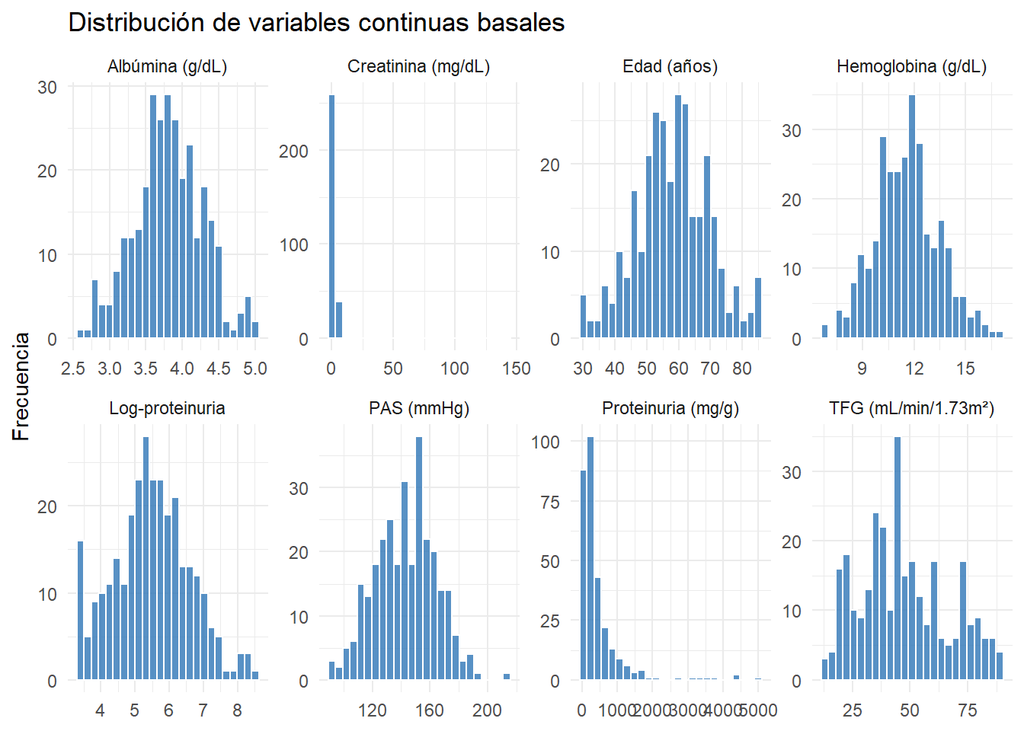

```r
base %>%
  select(edad, tfg_ml_min_basal, creatinina_mg_dl_basal,
         hemoglobina_g_dl_basal, albumina_g_dl_basal,
         proteinuria_mg_g_basal, pas_mmhg_basal,
         log_proteinuria_basal) %>%
  pivot_longer(everything(), names_to = "variable", values_to = "valor") %>%
  mutate(variable = recode(variable,
    "edad"                   = "Edad (años)",
    "tfg_ml_min_basal"       = "TFG (mL/min/1.73m²)",
    "creatinina_mg_dl_basal" = "Creatinina (mg/dL)",
    "hemoglobina_g_dl_basal" = "Hemoglobina (g/dL)",
    "albumina_g_dl_basal"    = "Albúmina (g/dL)",
    "proteinuria_mg_g_basal" = "Proteinuria (mg/g)",
    "pas_mmhg_basal"         = "PAS (mmHg)",
    "log_proteinuria_basal"  = "Log-proteinuria"
  )) %>%
  filter(!is.na(valor)) %>%
  ggplot(aes(x = valor)) +
  geom_histogram(bins = 25, fill = "#2E75B6", color = "white", alpha = 0.8) +
  facet_wrap(~variable, scales = "free", ncol = 4) +
  labs(title = "Distribución de variables continuas basales",
       x = NULL, y = "Frecuencia") +
  theme_minimal(base_size = 11)
```

**Interpretación:** Variables clínicas como la edad, presión arterial, hemoglobina y albúmina muestran una distribución aproximadamente simétrica o normal. Por el contrario, la proteinuria basal exhibe un marcado sesgo positivo (cola larga a la derecha). Como se observa en la gráfica, aplicar la transformación logarítmica (Log-proteinuria) normaliza eficazmente esta distribución, justificando su uso como covariable en los posteriores modelos de regresión.

## 4.2 Valores atípicos por estadio

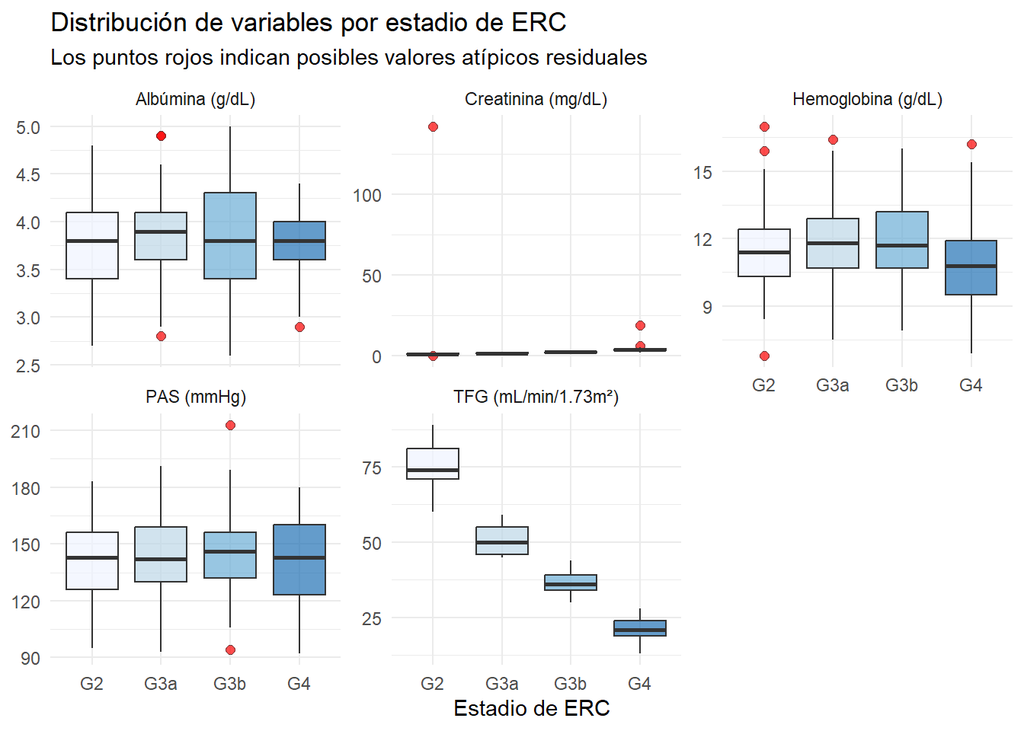

```r
base %>%
  select(estadio_basal, tfg_ml_min_basal, creatinina_mg_dl_basal,
         hemoglobina_g_dl_basal, albumina_g_dl_basal, pas_mmhg_basal) %>%
  pivot_longer(-estadio_basal,
               names_to  = "variable",
               values_to = "valor") %>%
  mutate(variable = recode(variable,
    "tfg_ml_min_basal"       = "TFG (mL/min/1.73m²)",
    "creatinina_mg_dl_basal" = "Creatinina (mg/dL)",
    "hemoglobina_g_dl_basal" = "Hemoglobina (g/dL)",
    "albumina_g_dl_basal"    = "Albúmina (g/dL)",
    "pas_mmhg_basal"         = "PAS (mmHg)"
  )) %>%
  filter(!is.na(valor)) %>%
  ggplot(aes(x = estadio_basal, y = valor, fill = estadio_basal)) +
  geom_boxplot(outlier.shape = 21, outlier.fill = "red",
               outlier.size = 2, alpha = 0.7) +
  scale_fill_brewer(palette = "Blues") +
  facet_wrap(~variable, scales = "free_y", ncol = 3) +
  labs(title = "Distribución de variables por estadio de ERC",
       subtitle = "Los puntos rojos indican posibles valores atípicos residuales",
       x = "Estadio de ERC", y = NULL) +
  theme_minimal(base_size = 11) +
  theme(legend.position = "none")
```

# 5 Evolución longitudinal de las variables clave

## 5.1 TFG a lo largo del seguimiento

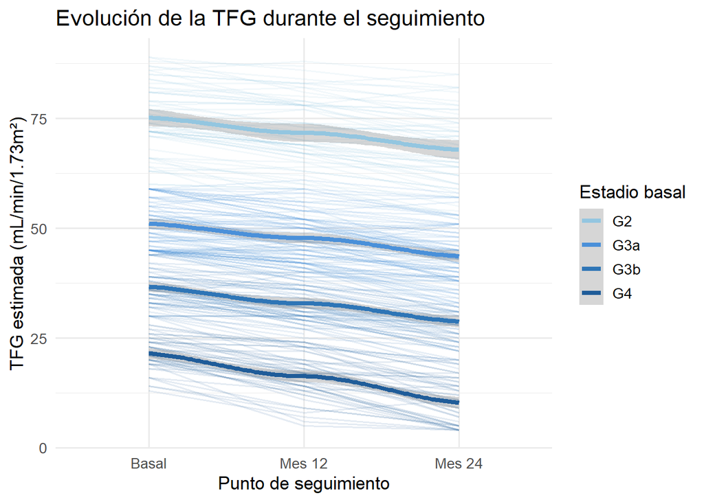

```r
base %>%
  select(id_estudio, estadio_basal,
         tfg_ml_min_basal, tfg_ml_min_m12, tfg_ml_min_m24) %>%
  pivot_longer(
    cols      = starts_with("tfg"),
    names_to  = "tiempo",
    values_to = "tfg"
  ) %>%
  mutate(
    tiempo = factor(tiempo,
                    levels = c("tfg_ml_min_basal",
                               "tfg_ml_min_m12",
                               "tfg_ml_min_m24"),
                    labels = c("Basal", "Mes 12", "Mes 24"))
  ) %>%
  filter(!is.na(tfg)) %>%
  ggplot(aes(x = tiempo, y = tfg,
             color = estadio_basal, group = id_estudio)) +
  geom_line(alpha = 0.12) +
  geom_smooth(aes(group = estadio_basal),
              method = "loess", se = TRUE, linewidth = 1.5) +
  scale_color_manual(values = c("G2"  = "#93C6E0",
                                 "G3a" = "#4A90D9",
                                 "G3b" = "#2E75B6",
                                 "G4"  = "#1F5C99")) +
  labs(
    title  = "Evolución de la TFG durante el seguimiento",
    x      = "Punto de seguimiento",
    y      = "TFG estimada (mL/min/1.73m²)",
    color  = "Estadio basal"
  ) +
  theme_minimal(base_size = 13)
```

```r
# Tasa de declive anual por estadio
base %>%
  filter(!is.na(tasa_declive_tfg)) %>%
  group_by(estadio_basal) %>%
  summarise(
    n = n(),
    mediana_declive = median(tasa_declive_tfg),
    p25 = quantile(tasa_declive_tfg, 0.25),
    p75 = quantile(tasa_declive_tfg, 0.75)
  ) %>%
  knitr::kable(
    digits = 1,
    col.names = c("Estadio", "N", "Mediana (mL/min/año)",
                  "P25", "P75"),
    caption = "Tabla. Tasa anual de declive de TFG por estadio basal"
  )
```

Tabla. Tasa anual de declive de TFG por estadio basal

| Estadio | N | Mediana (mL/min/año) | P25 | P75 |
| --- | --- | --- | --- | --- |
| G2 | 56 | -3.5 | -5.1 | -2.5 |
| G3a | 80 | -4.0 | -5.5 | -2.0 |
| G3b | 64 | -4.0 | -5.6 | -2.4 |
| G4 | 46 | -5.2 | -7.5 | -4.5 |

**Interpretación:** Se observa un claro gradiente clínico esperado: la tasa de declive de la TFG es progresivamente más acentuada en los estadios avanzados (particularmente en G4) respecto a los estadios iniciales (G2), lo que confirma el patrón acelerado de deterioro funcional renal característico de la ERC avanzada.

# 6 Correlaciones entre variables basales

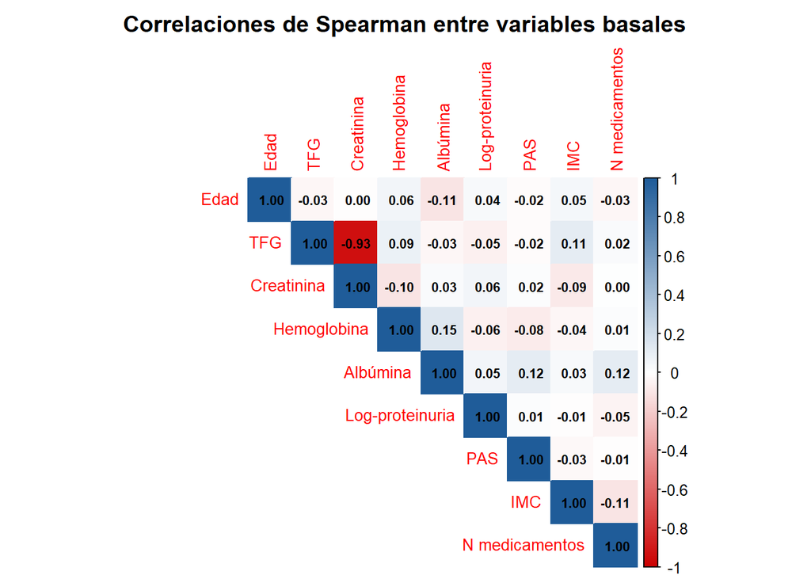

```r
vars_cor <- base %>%
  select(edad, tfg_ml_min_basal, creatinina_mg_dl_basal,
         hemoglobina_g_dl_basal, albumina_g_dl_basal,
         log_proteinuria_basal, pas_mmhg_basal,
         imc_calculado, n_medicamentos_totales) %>%
  na.omit()

cor_mat <- cor(vars_cor, method = "spearman")
colnames(cor_mat) <- rownames(cor_mat) <- c(
  "Edad", "TFG", "Creatinina",
  "Hemoglobina", "Albúmina",
  "Log-proteinuria", "PAS",
  "IMC", "N medicamentos"
)

corrplot(cor_mat,
         method      = "color",
         type        = "upper",
         tl.cex      = 0.85,
         addCoef.col = "black",
         number.cex  = 0.7,
         col = colorRampPalette(c("#CC0000", "white", "#1F5C99"))(200),
         title = "Correlaciones de Spearman entre variables basales",
         mar   = c(0, 0, 2, 0))
```